# Analysis for Supplementary Information 6

Alex Huebner `21/07/2020

- Results
  - Panel a: Summary of the assembly statistics of Wibowo et al.
  - Panel b - Overview of the simulation scheme
  - Panel c - Mismatch rate
  - Panel d - log2-ratio between C-to-T and other substitutions

The following script reproduces the analysis used to generate Extended Data Figure 9. It uses the results generated by the simulation workflow and the general statistics of the contig length, GC content, mean read length, coverage, and the amount of ancient DNA damage measured as the frequency of C-to-T substitutions at the 5’ read ends.

# Results

## Panel a: Summary of the assembly statistics of Wibowo et al.

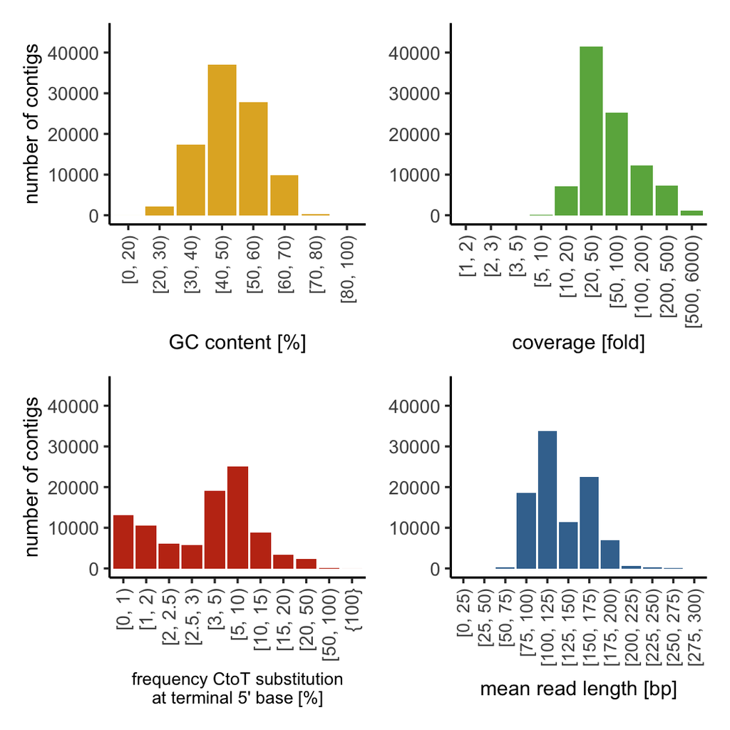

## Panel b - Overview of the simulation scheme

Based on the observed values in bins assembled in this study, we simulated short-read sequencing data with ancient DNA damage using gargammel (Renauld et al., 2017).

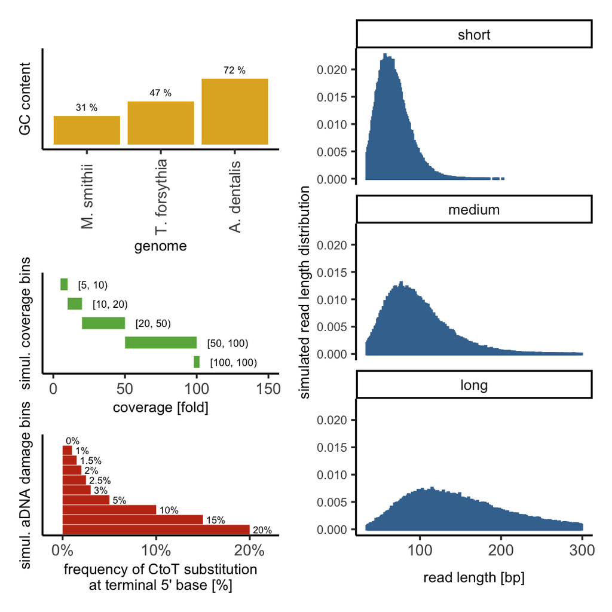

**Extended Data Figure 9b**: **Overview of the parameter space of the variables GC content, sequencing depth, observed aDNA damage, and read length that was used for simulating short-read sequencing using gargammel.**

## Panel c - Mismatch rate

Next, we evaluated the mismatch rate observed when aligning the consensus sequences of the assembled contigs back to the reference genomes.

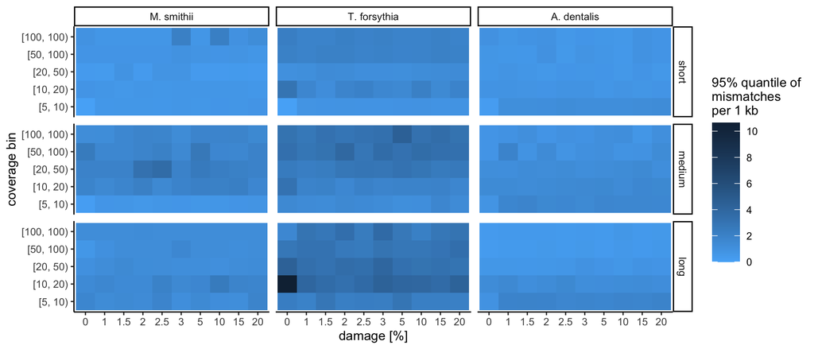

**Extended Data Figure 9c**: **Number of mismatches per 1 kb of alignable contig sequence with respect to the reference genome as observed at the 95% quantile for all combinations of reference genome, read length distribution, simulated aDNA damage, and coverage averaged across the five replicates.**

## Panel d - log2-ratio between C-to-T and other substitutions

Finally, we compared whether C-to-T substitutions that are indicative of an effect of ancient DNA damage in the consensus calling of contig sequences were more frequent than other substitutions.

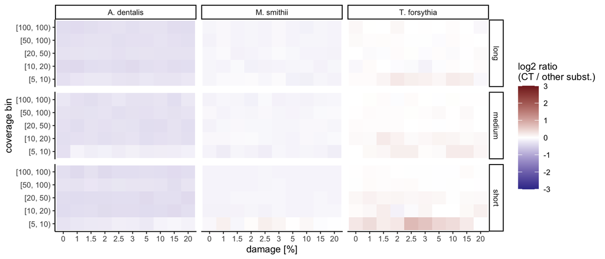

**Extended Data Figure 9d**: **Log2-ratio of C-to-T substitutions to the average number of all other substitutions per 1 kb of alignable contig sequence for all combinations of reference genome, read length distribution, simulated aDNA damage, and coverage averaged across the five replicates. Positive values indicate an excess of C-to-T substitutions.**